# Ch3 Final Project - Pets are humans too

## Step 1

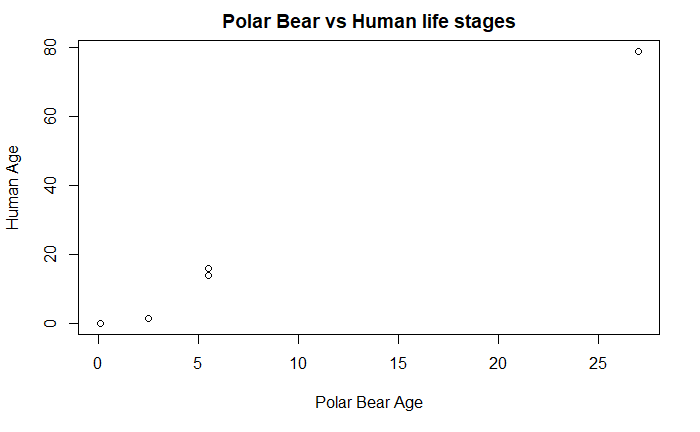

```r
humanlife = c(0.05, 1.5, 14, 16, 79)
bearlife = c(0.08, 2.5, 5.5, 5.5, 27)
plot(x = bearlife, y = humanlife,
   xlab = "Polar Bear Age",
   ylab = "Human Age",
   main = "Polar Bear vs Human life stages"
)
```

```r
print(paste0("r (correlation coefficient) is ", cor(humanlife, bearlife)))
```

```
[1] "r (correlation coefficient) is 0.997475921821457"
```

My explanatory variable is the age of the animal(Polar Bear) in years. My response variable is the age of a human in years corresponding to the developmental stage of the Polar Bear. I did this because the goal of this project is to find out what an animals “human age” is.

r = 0.997, indicating that there is a strong positive correlation between human and Polar Bear age.

## Step 2

#### Finding the regression line:

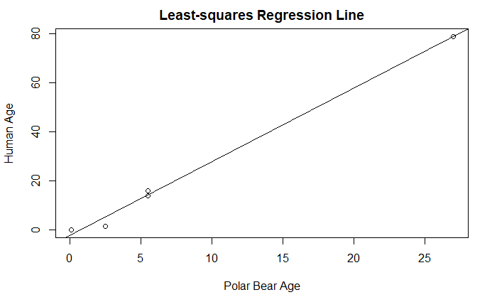

```r
regressionline <- lm(humanlife ~ bearlife)
plot(x = bearlife, y = humanlife, ylab="Human Age", xlab="Polar Bear Age",
     main="Least-squares Regression Line")
abline(-2.330, 3.011)
```

The least-squares regression equation is: ŷ = 3.011x - 2.33 or [human age] = 3.011(slope) x [bear age] - 2.33(intercept)

#### Predictions

Using this equation, the animals predicted human age corresponding to an age of 20 years is 57.89 years.

The animals age corresponding to a human age of 70 is 24.02 years.

These values seem pretty realistic, as the average lifespan of a Polar Bear is 27, vs 79 for humans.

For any Polar Bear age x, where 0 < x < 27, this model is a good predictor.

```r
print(paste0("R Squared (coefficient of determination) is ", summary(regressionline)$r.squared))
```

```
[1] "R Squared (coefficient of determination) is 0.994958214613566"
```

```r
residuals = resid(regressionline)
print(paste0("Standard deviation of the residuals is ", sd(residuals)))
```

```
[1] "Standard deviation of the residuals is 2.31476723146466"
```

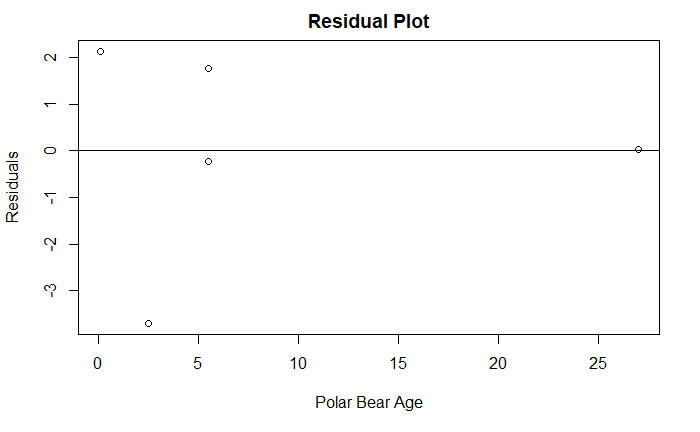

```r
plot(bearlife, residuals,
     ylab="Residuals", xlab="Polar Bear Age",
     main="Residual Plot")
abline(0, 0)
```

From this information, it seems like a linear model is a good fit. R squared is 99.5% and There is no apparent pattern in the residuals.

## Step 3

#### Transformation 1 - x vs ln(y) (Exponential)

Regression Equation is: ŷ = 1.21^x / 1.14

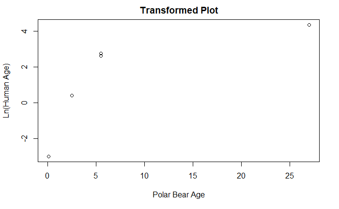

```r
transformationln <- function(x){
return(log(x))
}
lny <- unlist(lapply(humanlife, transformationln))
regressionlinet1 <- lm(lny ~ bearlife)
plot(x = bearlife, y = lny, ylab="Ln(Human Age)", xlab="Polar Bear Age",
     main="Transformed Plot")
```

```r
print(paste0("R Squared (coefficient of determination) is ", summary(regressionlinet1)$r.squared))
```

```
[1] "R Squared (coefficient of determination) is 0.53549385004327"
```

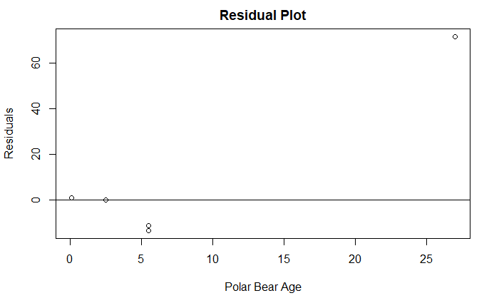

```r
calcpredictedyt1 <- function(x){
return(1.21^x/1.14)
}
predictedy <- unlist(lapply(bearlife, calcpredictedyt1))
residualst1 = c(0.8406724, -0.0872719, -11.49727, -13.49727, 71.76487)
plot(bearlife, residualst1,
     ylab="Residuals", xlab="Polar Bear Age",
     main="Residual Plot")
abline(0, 0)
```

There is a V pattern in the residuals, indicating that this model is not the best fit.

#### Transformation 2 - ln(x) vs ln(y) (Power)

Regression Equation is: y = 1.124x^1.296

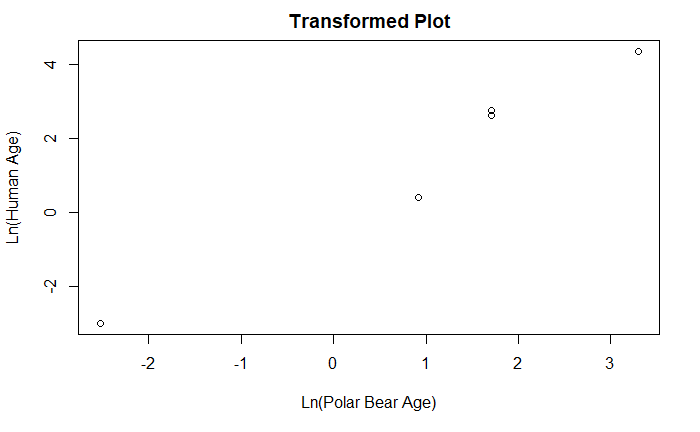

```r
lnx <- unlist(lapply(bearlife, transformationln))
lny <- unlist(lapply(humanlife, transformationln))
regressionlinet2 <- lm(lny ~ lnx)
plot(x = lnx, y = lny, ylab="Ln(Human Age)", xlab="Ln(Polar Bear Age)",
     main="Transformed Plot")
```

```r
print(paste0("R Squared (coefficient of determination) is ", summary(regressionlinet2)$r.squared))
```

```
[1] "R Squared (coefficient of determination) is 0.965233222395315"
```

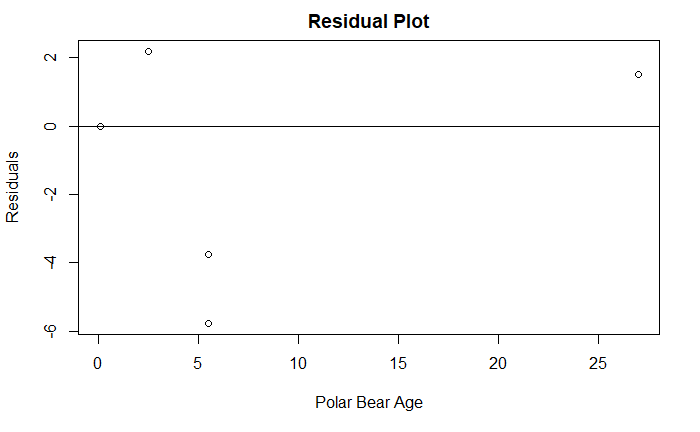

```r
calcpredictedyt2 <- function(x){
return(x^1.296*1.124)
}
predictedy <- unlist(lapply(bearlife, calcpredictedyt2))
residualst2 = c(-0.0074234, 2.185501, -3.760556, -5.760556, 1.503312)
plot(bearlife, residualst2,
     ylab="Residuals", xlab="Polar Bear Age",
     main="Residual Plot")
abline(0, 0)
```

There is a V pattern in the residuals, indicating that this model is not the best fit.

### Finding the best model

Based on the above findings, it is clear that a linear model is the best fit. This is what I expected as most animal growth follows the same trajectory.

The linear model had the best coefficient of determination of 99.5% compared to 53.5% and 96.5% of the other two models.

It is also easy to see that the transformed scatterplots are no where near as linear as the original non-transformed model.

In addition, the residual plot for the linear model has no apparent pattern, whereas there are clear V patterns in the residuals of the other models.

### Table

```r
calcpredictedy <- function(x){
return(3.011*x-2.33)
}
bearages = c(0.08, 1, 2.5, 3.5, 5.5, 6.5, 7.5, 8.5, 9.5, 10.5, 11.5, 15, 20, 25, 27)
predictedys <- unlist(lapply(bearages, calcpredictedy))
print(paste0("Bear Age", paste0("      ", "Predicted Human Age")))
```

```
[1] "Bear Age      Predicted Human Age"
```

```r
for (i in 1:length(bearages)) {
  print(paste0(bearages[i], paste0("      ", predictedys[i])))
}
```

```
[1] "0.08      -2.08912"
[1] "1      0.681"
[1] "2.5      5.1975"
[1] "3.5      8.2085"
[1] "5.5      14.2305"
[1] "6.5      17.2415"
[1] "7.5      20.2525"
[1] "8.5      23.2635"
[1] "9.5      26.2745"
[1] "10.5      29.2855"
[1] "11.5      32.2965"
[1] "15      42.835"
[1] "20      57.89"
[1] "25      72.945"
[1] "27      78.967"
```